# predicting_lung_cancer

Charles

Last compiled on 11 Oktober, 2024

# Lung Cancer Risk Dataset

## Overview

This dataset contains information related to various factors that may influence the risk of lung cancer. The data includes demographic information, lifestyle habits, and symptoms that are commonly associated with lung cancer. This dataset can be used to explore correlations, build predictive models, and identify potential risk factors for lung cancer.

## Columns:

- **GENDER**: The gender of the individual (e.g., M for male, F for female).
- **AGE**: The age of the individual in years.
- **SMOKING**: Indicates whether the individual is a smoker (Yes/No).
- **YELLOW_FINGERS**: Indicates whether the individual has yellow fingers (Yes/No).
- **ANXIETY**: Indicates whether the individual suffers from anxiety (Yes/No).
- **PEER_PRESSURE**: Indicates whether the individual is influenced by peer pressure (Yes/No).
- **CHRONIC_DISEASE**: Indicates whether the individual has any chronic disease (Yes/No).
- **FATIGUE**: Indicates whether the individual experiences fatigue (Yes/No).
- **ALLERGY**: Indicates whether the individual has allergies (Yes/No).
- **WHEEZING**: Indicates whether the individual has wheezing symptoms (Yes/No).
- **ALCOHOL_CONSUMING**: Indicates whether the individual consumes alcohol (Yes/No).
- **COUGHING**: Indicates whether the individual has a coughing symptom (Yes/No).
- **SHORTNESS_OF_BREATH**: Indicates whether the individual experiences shortness of breath (Yes/No).
- **SWALLOWING_DIFFICULTY**: Indicates whether the individual has difficulty swallowing (Yes/No).
- **CHEST_PAIN**: Indicates whether the individual experiences chest pain (Yes/No).
- **LUNG_CANCER**: Indicates whether the individual has been diagnosed with lung cancer (Yes/No).

## Example Record

- **GENDER**: M
- **AGE**: 65
- **SMOKING**: Yes
- **YELLOW_FINGERS**: Yes
- **ANXIETY**: Yes
- **PEER_PRESSURE**: No
- **CHRONIC_DISEASE**: No
- **FATIGUE**: Yes
- **ALLERGY**: No
- **WHEEZING**: No
- **ALCOHOL_CONSUMING**: No
- **COUGHING**: No
- **SHORTNESS_OF_BREATH**: No
- **SWALLOWING_DIFFICULTY**: No
- **CHEST_PAIN**: Yes
- **LUNG_CANCER**: NO

## loading libraries

```r
library(ggplot2) # visualisation
library(corrr) # for correlation
library(tidyverse) # data wrangling
library(patchwork) # visualisation
```

# Analyses

## Loading the dataset

The dataset is a csv file in the in the `raw_data` directory called `dataseter.csv`.

```r
data <- read.csv("raw_data/dataseter.csv")
head(data)
```

```
##   GENDER AGE SMOKING YELLOW_FINGERS ANXIETY PEER_PRESSURE CHRONIC_DISEASE
## 1      M  65     Yes            Yes     Yes            No              No
## 2      F  55     Yes             No      No           Yes             Yes
## 3      F  78      No             No     Yes           Yes             Yes
## 4      M  60      No            Yes     Yes           Yes              No
## 5      F  80     Yes            Yes      No           Yes             Yes
## 6      F  58     Yes            Yes     Yes            No              No
##   FATIGUE ALLERGY WHEEZING ALCOHOL_CONSUMING COUGHING SHORTNESS_OF_BREATH
## 1     Yes      No       No                No       No                  No
## 2      No      No       No               Yes      Yes                 Yes
## 3      No     Yes       No               Yes      Yes                  No
## 4     Yes      No      Yes               Yes       No                 Yes
## 5      No     Yes       No               Yes      Yes                 Yes
## 6      No      No      Yes                No       No                 Yes
##   SWALLOWING_DIFFICULTY CHEST_PAIN LUNG_CANCER
## 1                    No        Yes          NO
## 2                    No         No          NO
## 3                   Yes        Yes         YES
## 4                    No         No         YES
## 5                   Yes         No          NO
## 6                   Yes         No         YES
```

## Cleaning the data

Inspecting the dataset above makes us realise that almost all the entries are binary and in text format except the age which is numerical. To achieve consistency, it will be important to convert `Yes` to `1` and `No` to `0`.

```r
data[data == "Yes"] <- 1; data[data == "YES"] <- 1
data[data == "No"] <- 0;  data[data == "NO"] <- 0
head(data)
```

```
##   GENDER AGE SMOKING YELLOW_FINGERS ANXIETY PEER_PRESSURE CHRONIC_DISEASE
## 1      M  65       1              1       1             0               0
## 2      F  55       1              0       0             1               1
## 3      F  78       0              0       1             1               1
## 4      M  60       0              1       1             1               0
## 5      F  80       1              1       0             1               1
## 6      F  58       1              1       1             0               0
##   FATIGUE ALLERGY WHEEZING ALCOHOL_CONSUMING COUGHING SHORTNESS_OF_BREATH
## 1       1       0        0                 0        0                   0
## 2       0       0        0                 1        1                   1
## 3       0       1        0                 1        1                   0
## 4       1       0        1                 1        0                   1
## 5       0       1        0                 1        1                   1
## 6       0       0        1                 0        0                   1
##   SWALLOWING_DIFFICULTY CHEST_PAIN LUNG_CANCER
## 1                     0          1           0
## 2                     0          0           0
## 3                     1          1           1
## 4                     0          0           1
## 5                     1          0           0
## 6                     1          0           1
```

The gender column is binary and coded as `M` for male and `F` for female. Adjust such that male has the value of 1 and female the value of 0.

```r
data[data == "M"] <- 1
data[data == "F"] <- 0
head(data)
```

```
##   GENDER AGE SMOKING YELLOW_FINGERS ANXIETY PEER_PRESSURE CHRONIC_DISEASE
## 1      1  65       1              1       1             0               0
## 2      0  55       1              0       0             1               1
## 3      0  78       0              0       1             1               1
## 4      1  60       0              1       1             1               0
## 5      0  80       1              1       0             1               1
## 6      0  58       1              1       1             0               0
##   FATIGUE ALLERGY WHEEZING ALCOHOL_CONSUMING COUGHING SHORTNESS_OF_BREATH
## 1       1       0        0                 0        0                   0
## 2       0       0        0                 1        1                   1
## 3       0       1        0                 1        1                   0
## 4       1       0        1                 1        0                   1
## 5       0       1        0                 1        1                   1
## 6       0       0        1                 0        0                   1
##   SWALLOWING_DIFFICULTY CHEST_PAIN LUNG_CANCER
## 1                     0          1           0
## 2                     0          0           0
## 3                     1          1           1
## 4                     0          0           1
## 5                     1          0           0
## 6                     1          0           1
```

## Convert all characters to numeric

```r
str(data)
```

```
## 'data.frame':    3000 obs. of  16 variables:
##  $ GENDER               : chr  "1" "0" "0" "1" ...
##  $ AGE                  : int  65 55 78 60 80 58 70 74 77 67 ...
##  $ SMOKING              : chr  "1" "1" "0" "0" ...
##  $ YELLOW_FINGERS       : chr  "1" "0" "0" "1" ...
##  $ ANXIETY              : chr  "1" "0" "1" "1" ...
##  $ PEER_PRESSURE        : chr  "0" "1" "1" "1" ...
##  $ CHRONIC_DISEASE      : chr  "0" "1" "1" "0" ...
##  $ FATIGUE              : chr  "1" "0" "0" "1" ...
##  $ ALLERGY              : chr  "0" "0" "1" "0" ...
##  $ WHEEZING             : chr  "0" "0" "0" "1" ...
##  $ ALCOHOL_CONSUMING    : chr  "0" "1" "1" "1" ...
##  $ COUGHING             : chr  "0" "1" "1" "0" ...
##  $ SHORTNESS_OF_BREATH  : chr  "0" "1" "0" "1" ...
##  $ SWALLOWING_DIFFICULTY: chr  "0" "0" "1" "0" ...
##  $ CHEST_PAIN           : chr  "1" "0" "1" "0" ...
##  $ LUNG_CANCER          : chr  "0" "0" "1" "1" ...
```

I need to convert all character entries into numeric format in order to perform linear correlation.

```r
data[] <- sapply(data, as.numeric)
```

## Point-biserial correlation between age and binary variables.

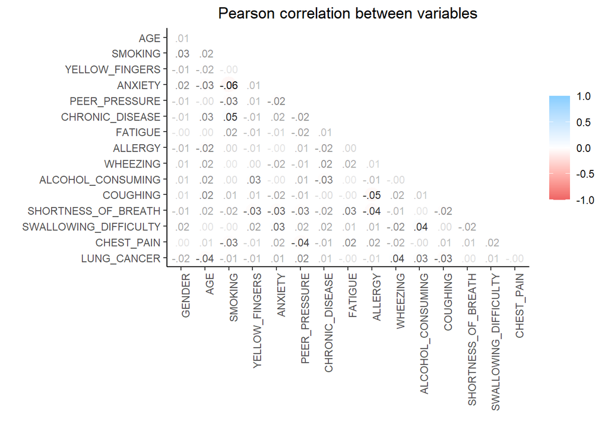

```r
data %>%
  select(where(is.numeric))%>%
  correlate()%>%
  shave()%>%
  rplot(print_cor =TRUE) +
  ggtitle("Pearson correlation between variables") +
  theme(axis.text.x = element_text(angle = 90, hjust = 1),
        plot.title = element_text(hjust = 0.5))
```

### Interpretation of Shaved Correlation Coefficients

The given table represents Pearson correlation coefficients between various terms in the lung cancer risk dataset. The coefficients range from -1 to 1, indicating the strength and direction of the linear relationship between pairs of variables.

- **Correlation Coefficient**: A value between -1 and 1 that indicates the strength and direction of the linear relationship between two variables.
  - `1` indicates a perfect positive correlation.
  - `-1` indicates a perfect negative correlation.
  - `0` indicates no linear correlation.

### Key Interpretations

1. **GENDER**:
   - GENDER and other variables have very low correlation values close to 0, indicating almost no linear relationship.
2. **AGE**:
   - AGE and other variables also show very low correlation values. For example, AGE and SMOKING have a correlation of 0.020, which is negligible.
3. **SMOKING**:
   - SMOKING shows very low correlations with other variables. The highest is with CHRONIC_DISEASE (0.046), which is still very weak.
4. **YELLOW_FINGERS**:
   - YELLOW_FINGERS has low correlations with all other variables. The highest correlation is with ALCOHOL_CONSUMING (0.027), which is insignificant.
5. **ANXIETY**:
   - ANXIETY shows slightly higher but still weak negative correlations with PEER_PRESSURE (-0.025) and SHORTNESS_OF_BREATH (-0.035).
6. **PEER_PRESSURE**:
   - PEER_PRESSURE has low correlations with all other variables, with the highest being with CHEST_PAIN (-0.039), which is still weak.
7. **CHRONIC_DISEASE**:
   - CHRONIC_DISEASE shows weak correlations with SMOKING (0.046) and WHEEZING (0.022).
8. **LUNG_CANCER**:
   - LUNG_CANCER shows weak correlations with most variables. The highest is with WHEEZING (0.039) and ALCOHOL_CONSUMING (0.030).

### General Observations

- **Overall Weak Correlations**: The majority of the correlations are very close to 0, suggesting that there are no strong linear relationships between any pairs of variables in this dataset.
- **Independent Variables**: Given the low correlation values, it seems the variables are fairly independent of each other.
- **Potential Outliers**: Low correlations might indicate potential outliers or non-linear relationships that aren’t captured by Pearson correlation.

### Example Insights

- **Age and Lung Cancer**: The correlation between AGE and LUNG_CANCER is -0.036, indicating no significant relationship.
- **Smoking and Lung Cancer**: The correlation between SMOKING and LUNG_CANCER is -0.014, indicating no significant relationship in this dataset.
- **Wheezing and Lung Cancer**: The correlation between WHEEZING and LUNG_CANCER is 0.039, the highest observed, but still very weak.

In summary, the dataset’s variables exhibit very weak correlations with each other, suggesting that any linear relationships are minimal or non-existent. For a more in-depth analysis, you may need to explore non-linear relationships or consider different statistical methods.

## correlate between categorical variables using the Chi squared test

```r
# convert to categorical
data <- data %>%
           mutate(across(.cols = -all_of("AGE"),
                         .fns = factor))

# Load necessary packages
library(tidyverse)
library(vcd)

# Function to perform chi-square test and generate plots
analyze_features <- function(feature) {
  # Create contingency table
  contingency_table <- table(data[[feature]], data$LUNG_CANCER)

  # Perform chi-square test
  chi_test <- chisq.test(contingency_table)

  # Print chi-square test result
  print(paste("Chi-square test result for", feature))

  return(chi_test)
}

categorical_features <- sapply(data, is.factor)
categorical_features <- categorical_features[categorical_features]
categorical_features <- names(categorical_features)[names(categorical_features) != "LUNG_CANCER"]

# Perform analysis for each symptom and collect results
results <- lapply(categorical_features, analyze_features)
```

```
## [1] "Chi-square test result for GENDER"
## [1] "Chi-square test result for SMOKING"
## [1] "Chi-square test result for YELLOW_FINGERS"
## [1] "Chi-square test result for ANXIETY"
## [1] "Chi-square test result for PEER_PRESSURE"
## [1] "Chi-square test result for CHRONIC_DISEASE"
## [1] "Chi-square test result for FATIGUE"
## [1] "Chi-square test result for ALLERGY"
## [1] "Chi-square test result for WHEEZING"
## [1] "Chi-square test result for ALCOHOL_CONSUMING"
## [1] "Chi-square test result for COUGHING"
## [1] "Chi-square test result for SHORTNESS_OF_BREATH"
## [1] "Chi-square test result for SWALLOWING_DIFFICULTY"
## [1] "Chi-square test result for CHEST_PAIN"
```

```r
# Summarize chi-square test results in a data frame
summary_results <- data.frame(
  features = categorical_features,
  ChiSquare = sapply(results, function(x) x$statistic),
  pValue = sapply(results, function(x) x$p.value)
)

# Print summary of results
summary_results <- summary_results[order(summary_results$pValue, decreasing = F), ]
knitr::kable(summary_results,
             caption = "Features vs lung cancer Chi squared test",
             "pipe")
```

Features vs lung cancer Chi squared test

|  | features | ChiSquare | pValue |
| --- | --- | --- | --- |
| 9 | WHEEZING | 4.3181649 | 0.0377076 |
| 11 | COUGHING | 3.1532429 | 0.0757762 |
| 10 | ALCOHOL_CONSUMING | 2.6638736 | 0.1026505 |
| 5 | PEER_PRESSURE | 1.7248010 | 0.1890762 |
| 1 | GENDER | 0.7158404 | 0.3975117 |
| 4 | ANXIETY | 0.5761321 | 0.4478324 |
| 2 | SMOKING | 0.5510111 | 0.4579048 |
| 3 | YELLOW_FINGERS | 0.4565597 | 0.4992362 |
| 6 | CHRONIC_DISEASE | 0.2746290 | 0.6002434 |
| 13 | SWALLOWING_DIFFICULTY | 0.1803835 | 0.6710439 |
| 8 | ALLERGY | 0.1023497 | 0.7490279 |
| 14 | CHEST_PAIN | 0.0123889 | 0.9113740 |
| 12 | SHORTNESS_OF_BREATH | 0.0087992 | 0.9252650 |
| 7 | FATIGUE | 0.0075061 | 0.9309593 |

Based on the Chi-squared test results, here’s an interpretation of the significance of each feature with respect to the event of having lung cancer:

1. **WHEEZING**:
   - ChiSquare: 4.318
   - pValue: 0.038
   - **Interpretation**: There is a statistically significant association between wheezing and lung cancer at the 0.05 significance level.
2. **COUGHING**:
   - ChiSquare: 3.153
   - pValue: 0.076
   - **Interpretation**: The association between coughing and lung cancer is not statistically significant at the 0.05 significance level, but it is close. This feature might still be important and could warrant further investigation.
3. **ALCOHOL_CONSUMING**:
   - ChiSquare: 2.664
   - pValue: 0.103
   - **Interpretation**: There is no statistically significant association between alcohol consumption and lung cancer.
4. **PEER_PRESSURE**:
   - ChiSquare: 1.725
   - pValue: 0.189
   - **Interpretation**: There is no statistically significant association between peer pressure and lung cancer.
5. **GENDER**:
   - ChiSquare: 0.716
   - pValue: 0.398
   - **Interpretation**: There is no statistically significant association between gender and lung cancer.
6. **ANXIETY**:
   - ChiSquare: 0.576
   - pValue: 0.448
   - **Interpretation**: There is no statistically significant association between anxiety and lung cancer.
7. **SMOKING**:
   - ChiSquare: 0.551
   - pValue: 0.458
   - **Interpretation**: There is no statistically significant association between smoking and lung cancer in this dataset, which is surprising and might warrant further investigation or a review of the data.
8. **YELLOW_FINGERS**:
   - ChiSquare: 0.457
   - pValue: 0.499
   - **Interpretation**: There is no statistically significant association between yellow fingers and lung cancer.
9. **CHRONIC_DISEASE**:
   - ChiSquare: 0.275
   - pValue: 0.600
   - **Interpretation**: There is no statistically significant association between chronic disease and lung cancer.
10. **SWALLOWING_DIFFICULTY**:
    - ChiSquare: 0.180
    - pValue: 0.671
    - **Interpretation**: There is no statistically significant association between swallowing difficulty and lung cancer.
11. **ALLERGY**:
    - ChiSquare: 0.102
    - pValue: 0.749
    - **Interpretation**: There is no statistically significant association between allergy and lung cancer.
12. **CHEST_PAIN**:
    - ChiSquare: 0.012
    - pValue: 0.911
    - **Interpretation**: There is no statistically significant association between chest pain and lung cancer.
13. **SHORTNESS_OF_BREATH**:
    - ChiSquare: 0.009
    - pValue: 0.925
    - **Interpretation**: There is no statistically significant association between shortness of breath and lung cancer.
14. **FATIGUE**:
    - ChiSquare: 0.008
    - pValue: 0.931
    - **Interpretation**: There is no statistically significant association between fatigue and lung cancer.

### Summary

Only the feature **WHEEZING** shows a statistically significant association with lung cancer at the 0.05 level. The other features do not show significant associations based on the provided p-values. This suggests that wheezing might be a potential indicator or risk factor for lung cancer and may warrant further investigation or consideration in predictive models.

## Lasso regression for feature engineering

```r
library(glmnet)
library(caret)
library(pROC)

# Separate features and target
X <- model.matrix(LUNG_CANCER ~ ., data)[, -1]  # Create a model matrix and remove the intercept
y <- data$LUNG_CANCER

# Split the data
set.seed(123)
trainIndex <- createDataPartition(y, p = .8, list = FALSE, times = 1)
X_train <- X[trainIndex, ]
X_test <- X[-trainIndex, ]
y_train <- y[trainIndex]
y_test <- y[-trainIndex]

# Standardize the continuous feature (age)
# Note: glmnet automatically standardizes the features internally

# Fit the Lasso Logistic Regression model with cross-validation
cv.lasso <- cv.glmnet(X_train, y_train, alpha = 1, family = "binomial")

# Get the best lambda (regularization parameter)
best_lambda <- cv.lasso$lambda.min

# Fit the final model on the training data
lasso_model <- glmnet(X_train, y_train, alpha = 1, lambda = best_lambda, family = "binomial")

# Predict and evaluate the model
pred_probs <- predict(lasso_model, s = best_lambda, newx = X_test, type = "response")
predictions <- ifelse(pred_probs > 0.5, 1, 0)

# Evaluate performance
conf_matrix <- confusionMatrix(as.factor(predictions), as.factor(y_test))
accuracy <- conf_matrix$overall['Accuracy']
precision <- conf_matrix$byClass['Pos Pred Value']
recall <- conf_matrix$byClass['Sensitivity']

# Calculate ROC AUC
roc_obj <- roc(y_test, pred_probs)
roc_auc <- auc(roc_obj)

print(paste('Accuracy:', accuracy))
```

```
## [1] "Accuracy: 0.50584307178631"
```

```r
print(paste('Precision:', precision))
```

```
## [1] "Precision: NaN"
```

```r
print(paste('Recall:', recall))
```

```
## [1] "Recall: 0"
```

```r
print(paste('ROC-AUC:', roc_auc))
```

```
## [1] "ROC-AUC: 0.5"
```

```r
# Identify selected features
selected_features <- rownames(coef(lasso_model, s = best_lambda))[which(coef(lasso_model, s = best_lambda) != 0)]
print('Selected Features:')
```

```
## [1] "Selected Features:"
```

```r
selected_features <- selected_features[-grep("inter", selected_features, ignore.case = T)]
```

If wheezing is the only feature with a non-zero coefficient after performing Lasso logistic regression, it indicates that wheezing is the most important predictor of the binary outcome having lung cancer. Here’s a detailed interpretation:

### Example Code to Extract and Interpret the Coefficient

Here’s how you can extract and interpret the coefficient for wheezing in R:

```r
# Extract the coefficients of the final model
coef_matrix <- coef(lasso_model, s = best_lambda)

# Convert the sparse matrix to a data frame
coef_df <- as.data.frame(as.matrix(coef_matrix))
coef_df$Feature <- rownames(coef_df)

# Filter to keep only the selected features (non-zero coefficients)
selected_coef_df <- coef_df[coef_df$s1 != 0, ]

# Print the coefficients of the selected features
print('Selected Features and their Coefficients:')
```

```
## [1] "Selected Features and their Coefficients:"
```

```r
print(selected_coef_df)
```

```
##                       s1     Feature
## (Intercept) 2.415778e-02 (Intercept)
## WHEEZING1   5.553082e-17   WHEEZING1
```

## T test between age and lung cancer

```r
lc <- data[data$LUNG_CANCER == 1, ]$AGE
no_lc <- data[data$LUNG_CANCER == 1, ]$AGE

var.test(lc, no_lc)
```

```
##
##  F test to compare two variances
##
## data:  lc and no_lc
## F = 1, num df = 1517, denom df = 1517, p-value = 1
## alternative hypothesis: true ratio of variances is not equal to 1
## 95 percent confidence interval:
##  0.9042212 1.1059241
## sample estimates:
## ratio of variances
##                  1
```

```r
t.test(lc, no_lc, var.equal = T)
```

```
##
##  Two Sample t-test
##
## data:  lc and no_lc
## t = 0, df = 3034, p-value = 1
## alternative hypothesis: true difference in means is not equal to 0
## 95 percent confidence interval:
##  -1.060663  1.060663
## sample estimates:
## mean of x mean of y
##  54.64954  54.64954
```

#### t-test Output

```
    Two Sample t-test

data:  lc and no_lc
t = 0, df = 3034, p-value = 1
alternative hypothesis: true difference in means is not equal to 0
95 percent confidence interval:
 -1.060663  1.060663
sample estimates:
mean of x mean of y
 54.64954  54.64954
```

## Logistic regression

```r
library(ResourceSelection)

lmod <- glm(LUNG_CANCER ~  WHEEZING, family = binomial,  data = data)
summary(lmod)
```

```
##
## Call:
## glm(formula = LUNG_CANCER ~ WHEEZING, family = binomial, data = data)
##
## Coefficients:
##             Estimate Std. Error z value Pr(>|z|)
## (Intercept) -0.05363    0.05180  -1.035   0.3005
## WHEEZING1    0.15451    0.07309   2.114   0.0345 *
## ---
## Signif. codes:  0 '***' 0.001 '**' 0.01 '*' 0.05 '.' 0.1 ' ' 1
##
## (Dispersion parameter for binomial family taken to be 1)
##
##     Null deviance: 4158.5  on 2999  degrees of freedom
## Residual deviance: 4154.0  on 2998  degrees of freedom
## AIC: 4158
##
## Number of Fisher Scoring iterations: 3
```

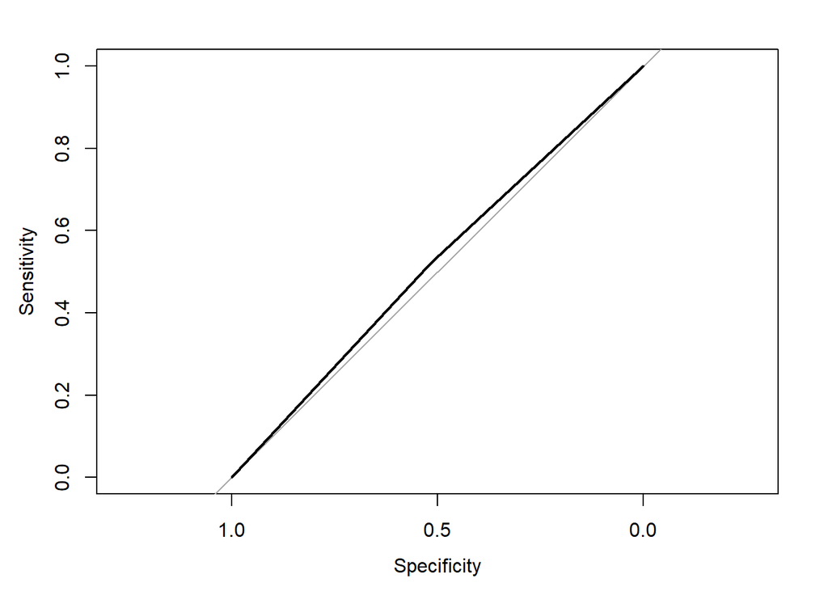

```r
# Predict probabilities
pred_probs <- predict(lmod, type = "response")

# Plot ROC curve and calculate AUC
roc_obj <- roc(data$LUNG_CANCER, pred_probs)
plot(roc_obj)
```

```r
auc_value <- auc(roc_obj)
print(paste('AUC:', auc_value))
```

```
## [1] "AUC: 0.519304113125623"
```

An AUC (Area Under the Curve) of 0.519 indicates that the model has a poor ability to discriminate between the two classes (having lung cancer or not). An AUC close to 0.5 suggests that the model is performing no better than random chance.

**Interpretation and Next Steps** Given the low AUC, it’s important to reassess the model and potentially make improvements. Here are some steps to consider:

**Feature Engineering:** Add or transform features to capture more information. **Model Complexity:** Consider more complex models if logistic regression is too simplistic. **Regularization:** Ensure that regularization parameters are properly tuned. **Check Data Quality:** Ensure the data is clean and the features are meaningful